# Text Mining Sections - Fold into main report

# 1 Deciding on negative sentiment cutoffs

*[BELOW FOR INTERNAL DISCUSSION ONLY]*

Let’s look at the distributions of our outcome variables of interest first (potentially this can be folded into EDA):

```r
data <- read_csv("data/data.csv")
# Distribution of both thermometers
summary(data$dem_therm)
```

```
##    Min. 1st Qu.  Median    Mean 3rd Qu.    Max.    NA's
##   -8.00   20.00   50.00   49.33   70.00   97.00     346
```

```r
summary(data$rep_therm)
```

```
##    Min. 1st Qu.  Median    Mean 3rd Qu.    Max.    NA's
##   -8.00   15.00   50.00   43.18   70.00   97.00     387
```

```r
table(data$dem_therm)[c("0", "10", "20", "30", "40","50", "60", "70", "80", "90" , "100")]
```

```
##
##    0   10   20   30   40   50   60   70   80   90 <NA>
## 3769  266  172 1623 1759 2889 2814 3099  333  237
```

```r
table(data$rep_therm)[c("0", "10", "20", "30", "40","50", "60", "70", "80", "90" , "100")]
```

```
##
##    0   10   20   30   40   50   60   70   80   90 <NA>
## 4209  402  226 2207 2096 3258 2686 2509  186  207
```

```r
# Save to file
png("data/text_mining_output/viz_cdf.png", width = 1200, height = 600, res = 150)
par(mfrow = c(1,2))
plot(ecdf(data$dem_therm),
     main = "CDF: Democrat Thermometer",
     xlab = "Feeling (0-100)", ylab = "Cumulative Proportion",
     col = "steelblue", lwd = 2, verticals = TRUE, do.points = FALSE)
abline(v = c(20, 40, 60, 80), col = "gray", lty = 2)
abline(h = 0.5, col = "red", lty = 2)
plot(ecdf(data$rep_therm),
     main = "CDF: Republican Thermometer",
     xlab = "Feeling (0-100)", ylab = "Cumulative Proportion",
     col = "tomato", lwd = 2, verticals = TRUE, do.points = FALSE)
abline(v = c(20, 40, 60, 80), col = "gray", lty = 2)
abline(h = 0.5, col = "red", lty = 2)
par(mfrow = c(1,1))
dev.off()
```

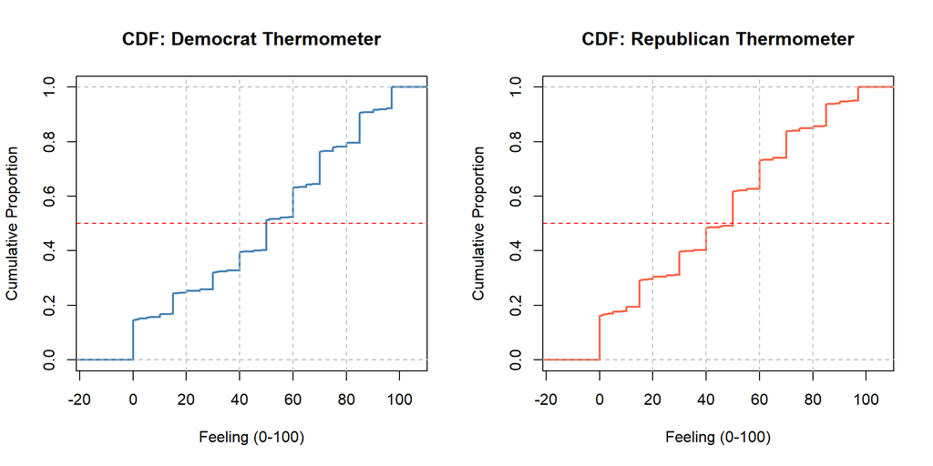

```r
# Display inline
par(mfrow = c(1,2))
plot(ecdf(data$dem_therm),
     main = "CDF: Democrat Thermometer",
     xlab = "Feeling (0-100)", ylab = "Cumulative Proportion",
     col = "steelblue", lwd = 2, verticals = TRUE, do.points = FALSE)
abline(v = c(20, 40, 60, 80), col = "gray", lty = 2)
abline(h = 0.5, col = "red", lty = 2)
plot(ecdf(data$rep_therm),
     main = "CDF: Republican Thermometer",
     xlab = "Feeling (0-100)", ylab = "Cumulative Proportion",
     col = "tomato", lwd = 2, verticals = TRUE, do.points = FALSE)
abline(v = c(20, 40, 60, 80), col = "gray", lty = 2)
abline(h = 0.5, col = "red", lty = 2)
```

```r
par(mfrow = c(1,1))
```

Note: Check what the negative values are (e.g., -8 could be non-response). Clean data for now:

```r
data <- data %>%
  mutate(
    dem_therm = if_else(dem_therm < 0, NA, dem_therm),
    rep_therm = if_else(rep_therm < 0, NA, rep_therm)
  )
```

The median for both parties falls at 50. There are a significant large proportion of partisans at zero thermometer for both parties.

There is an interesting temporal component to understand how animosity has changed over time in the EDA.

```r
data <- read_csv("data/data.csv") %>%
  mutate(
    dem_therm = if_else(dem_therm < 0, NA, dem_therm),
    rep_therm = if_else(rep_therm < 0, NA, rep_therm),
    dem_therm_cat = case_when(
      dem_therm < 20  ~ 1L,  # highly unfavorable
      dem_therm < 40  ~ 2L,  # unfavorable
      dem_therm < 60  ~ 3L,  # neutral
      dem_therm < 80  ~ 4L,  # favorable
      dem_therm >= 80 ~ 5L,  # highly favorable
      .default = NA_integer_
    ),
    rep_therm_cat = case_when(
      rep_therm < 20  ~ 1L,
      rep_therm < 40  ~ 2L,
      rep_therm < 60  ~ 3L,
      rep_therm < 80  ~ 4L,
      rep_therm >= 80 ~ 5L,
      .default = NA_integer_
    )
  )
prop.table(table(data$dem_therm_cat)) |> round(3)
prop.table(table(data$rep_therm_cat)) |> round(3)
```

These bands are all are substantive - though it is interesting that when people dislike the parties, they tend to really dislike them.

# 2 Step 1: Create corpora, clean corpora and create DTMs

## 2.1 Create corpora

We created the multiclass outcomes for the thermometer in the previous section.

We now want to consolidate the free response sections:

- Free text responses about Democrats: ‘dem_like’ and ‘dem_dislike’ into ‘dem_text’
- Free text responses about Republicans: ‘rep_like’ and ‘rep_dislike’ into ‘rep_text’

```r
data <- data %>%
  mutate(
    dem_text = paste(
      if_else(is.na(dem_like), "", dem_like),
      if_else(is.na(dem_dislike), "", dem_dislike)
    ),
    rep_text = paste(
      if_else(is.na(rep_like), "", rep_like),
      if_else(is.na(rep_dislike), "", rep_dislike)
    )
  )

# Quick check
data %>% select(dem_text, rep_text) %>% head(10)
```

We then build these into the corpora:

- `VCorpus()`: create Volatile Corpus
- `inspect()`: display detailed info of a corpus

```r
mycorpus.dem <- VCorpus(VectorSource(data$dem_text))
mycorpus.rep <- VCorpus(VectorSource(data$rep_text))

# Inspect a few documents
lapply(mycorpus.dem[1:5], as.character)
lapply(mycorpus.rep[1:5], as.character)
```

From this we can see the dataset still includes non-respondents to these questions. We can keep them in the dataset for now, but add a new variable to flag respondnets / non-respondents, and then retain only respondents with text-responses.

```r
# Flag respondents with usable text, but keep all rows in data
data <- data %>%
  mutate(
    has_dem_text = trimws(dem_text) != "",
    has_rep_text = trimws(rep_text) != ""
  )

# How many have usable text?
table(data$has_dem_text)
table(data$has_rep_text)

# Subsets for text mining only
data.dem.tm <- data %>% filter(has_dem_text)
data.rep.tm <- data %>% filter(has_rep_text)

cat("Dem text mining sample:", nrow(data.dem.tm), "\n")
cat("Rep text mining sample:", nrow(data.rep.tm), "\n")
```

The large proportion of non-text respondents (~40% for each party) is substantial, validating the Heckman approach for selection effects as a potential study extension. We will rebuild the corpora without these responses:

```r
#Recreate corpora using only the 'text mining' data (i.e., excluding non-respondents)
mycorpus.dem <- VCorpus(VectorSource(data.dem.tm$dem_text))
mycorpus.rep <- VCorpus(VectorSource(data.rep.tm$rep_text))

lapply(mycorpus.dem[1:5], as.character)
lapply(mycorpus.rep[1:5], as.character)
```

## 2.2 Clean corpora

We will create a two different sets of cleaned corpora:

- ‘Stemmed corpora’ - for basic stem text mining analysis - removes punctuation
- ‘N-gram / ski-gram’ corpora’ - keeps punctuation. we do need to need to bother with, for instance, converting periods to the word ‘PERIOD’ as suggested in the lecture, because we are not really dealing with full sentences.

```r
# Cleaning steps for all corpora
clean_corpus <- function(corpus, remove_punct = TRUE) {
  corpus <- tm_map(corpus, content_transformer(tolower))
  corpus <- tm_map(corpus, removeWords, stopwords("english"))
  if (remove_punct) corpus <- tm_map(corpus, removePunctuation)
  corpus <- tm_map(corpus, removeNumbers)
  corpus <- tm_map(corpus, stripWhitespace)
  corpus
}

# Stem corpora - remove punctuation and stem
mycorpus.dem.stem <- clean_corpus(mycorpus.dem, remove_punct = TRUE)
mycorpus.dem.stem <- tm_map(mycorpus.dem.stem, stemDocument, lazy = TRUE)

mycorpus.rep.stem <- clean_corpus(mycorpus.rep, remove_punct = TRUE)
mycorpus.rep.stem <- tm_map(mycorpus.rep.stem, stemDocument, lazy = TRUE)

#N-gram / skip-gram (keep punctuation)
mycorpus.dem.ngram <- clean_corpus(mycorpus.dem, remove_punct = FALSE)
mycorpus.rep.ngram <- clean_corpus(mycorpus.rep, remove_punct = FALSE)
```

```r
# Check corpora
cat("=== Dem stem corpus ===\n")
lapply(mycorpus.dem.stem[1:5], as.character)

cat("=== Rep stem corpus ===\n")
lapply(mycorpus.rep.stem[1:5], as.character)
```

## 2.3 Build DTMs

We will be building six DTMs in total: two sets of Stem, N-gram, and skip-gram DTMs respectively for Republicans and Democrats.

```r
# Stem DTMs

dtm.dem.stem <- DocumentTermMatrix(mycorpus.dem.stem) |>
  removeSparseTerms(1 - 0.01)

dtm.rep.stem <- DocumentTermMatrix(mycorpus.rep.stem) |>
  removeSparseTerms(1 - 0.01)

cat("=== Dem stem DTM ===\n"); inspect(dtm.dem.stem)
cat("=== Rep stem DTM ===\n"); inspect(dtm.rep.stem)
```

```r
# N-gram DTMs

ngram_tokenizer <- function(x, n = 2) {
  unlist(lapply(ngrams(words(x), 1:n), paste, collapse = "_"), use.names = FALSE)
}

dtm.dem.ngram <- DocumentTermMatrix(
  mycorpus.dem.ngram,
  control = list(tokenize = function(x) ngram_tokenizer(x, 2))
) |> removeSparseTerms(1 - 0.01)

dtm.rep.ngram <- DocumentTermMatrix(
  mycorpus.rep.ngram,
  control = list(tokenize = function(x) ngram_tokenizer(x, 2))
) |> removeSparseTerms(1 - 0.01)

cat("=== Dem n-gram DTM ===\n"); inspect(dtm.dem.ngram)
cat("=== Rep n-gram DTM ===\n"); inspect(dtm.rep.ngram)
```

```r
# Skip-gram DTMs - takes a few minutes to run!!
skipgram_tokenizer <- function(x, n = 2, k = 2) {
  toks <- words(x)
  if (length(toks) < 2) return(character(0))
  # tidytext expects a data frame input
  df <- data.frame(text = paste(toks, collapse = " "), stringsAsFactors = FALSE)
  sg <- tidytext::unnest_tokens(df, ngram, text,
                                 token = "skip_ngrams",
                                 n = n, k = k)
  sg$ngram
}

dtm.dem.skip <- DocumentTermMatrix(
  mycorpus.dem.ngram,
  control = list(tokenize = function(x) skipgram_tokenizer(x, n = 2, k = 2))
) |> removeSparseTerms(1 - 0.01)

dtm.rep.skip <- DocumentTermMatrix(
  mycorpus.rep.ngram,
  control = list(tokenize = function(x) skipgram_tokenizer(x, n = 2, k = 2))
) |> removeSparseTerms(1 - 0.01)

cat("=== Dem skip-gram DTM ===\n"); inspect(dtm.dem.skip)
cat("=== Rep skip-gram DTM ===\n"); inspect(dtm.rep.skip)
```

## 2.4 Multinomial LASSO models (Full sample)

We will run two sets of models - one with the full sample, and the other with only partisan out-party samples. First lets trim the glm model

```r
# Helper function to strip GLM fat (from lecture)
stripGlmLR <- function(cm) {
  cm$y = c(); cm$model = c(); cm$residuals = c()
  cm$fitted.values = c(); cm$effects = c(); cm$qr$qr = c()
  cm$linear.predictors = c(); cm$weights = c()
  cm$prior.weights = c(); cm$data = c()
  cm$family$variance = c(); cm$family$dev.resids = c()
  cm$family$aic = c(); cm$family$validmu = c()
  cm$family$simulate = c()
  attr(cm$terms, ".Environment") = c()
  attr(cm$formula, ".Environment") = c()
  cm
}
```

### 2.4.1 Run all six models (full sample)

A template model of the analysis can be found in earlier versions of the script. We can run this template for all six models as follows.

Setup:

```r
# Remove "year" and "years" from all DTMs to avoid model matrix conflicts
remove_terms <- c("year", "years")

dtm.dem.stem  <- dtm.dem.stem[,  !colnames(dtm.dem.stem)  %in% remove_terms]
dtm.dem.ngram <- dtm.dem.ngram[, !colnames(dtm.dem.ngram) %in% remove_terms]
dtm.dem.skip  <- dtm.dem.skip[,  !colnames(dtm.dem.skip)  %in% remove_terms]
dtm.rep.stem  <- dtm.rep.stem[,  !colnames(dtm.rep.stem)  %in% remove_terms]
dtm.rep.ngram <- dtm.rep.ngram[, !colnames(dtm.rep.ngram) %in% remove_terms]
dtm.rep.skip  <- dtm.rep.skip[,  !colnames(dtm.rep.skip)  %in% remove_terms]


model_specs <- list(
  list(name = "1a_dem_stem",  dtm = dtm.dem.stem,  data = data.dem.tm, outcome = "dem_therm_cat"),
  list(name = "1b_dem_ngram", dtm = dtm.dem.ngram, data = data.dem.tm, outcome = "dem_therm_cat"),
  list(name = "1c_dem_skip",  dtm = dtm.dem.skip,  data = data.dem.tm, outcome = "dem_therm_cat"),
  list(name = "2a_rep_stem",  dtm = dtm.rep.stem,  data = data.rep.tm, outcome = "rep_therm_cat"),
  list(name = "2b_rep_ngram", dtm = dtm.rep.ngram, data = data.rep.tm, outcome = "rep_therm_cat"),
  list(name = "2c_rep_skip",  dtm = dtm.rep.skip,  data = data.rep.tm, outcome = "rep_therm_cat")
)

all_results <- list()
```

Then we can join the datasets and design the sparse model matrices:

```r
for (spec in model_specs) {
  cat("\n=== Building data:", spec$name, "===\n")

  dtm_mat <- as.matrix(spec$dtm)
  outcome_vec <- as.factor(spec$data[[spec$outcome]])

  model_data <- data.frame(
    outcome = outcome_vec,
    year    = as.factor(spec$data$year),
    dtm_mat
  ) %>%
    filter(!is.na(outcome)) %>%
    mutate(year = droplevels(year))

  X <- sparse.model.matrix(outcome ~ ., data = model_data)[, -1]
  year_cols <- grep("^year", colnames(X))
  penalty <- rep(1, ncol(X))
  penalty[year_cols] <- 0

  cat("Sample size:", nrow(model_data), "\n")
  cat("Year dummies:", colnames(X)[year_cols], "\n")
  cat("Outcome distribution:\n")
  print(prop.table(table(model_data$outcome)) |> round(3))

  all_results[[spec$name]] <- list(
    X          = X,
    y          = model_data$outcome,
    penalty    = penalty,
    model_data = model_data
  )
}
```

As before, the outcome variable distributions match the outcome data we joined on. Next we can run LASSO, cacheing to avoid time-consuming re-runs.

```r
for (spec in model_specs) {
  cat("\n=== LASSO:", spec$name, "===\n")

  set.seed(5710)
  lasso_fit <- cv.glmnet(
    x              = all_results[[spec$name]]$X,
    y              = all_results[[spec$name]]$y,
    alpha          = 0.99,
    family         = "multinomial",
    type.measure   = "class",
    penalty.factor = all_results[[spec$name]]$penalty
  )

  cat("lambda.1se:", lasso_fit$lambda.1se, "\n")
  cat("lambda.min:", lasso_fit$lambda.min, "\n")

  all_results[[spec$name]]$lasso <- lasso_fit
  all_results[[spec$name]]$coefs <- coef(lasso_fit, s = "lambda.1se")
}

# Save after LASSO — so we don't have to rerun if R crashes
save(all_results, file = "data/lasso_results_setA.RData")
```

We can then view the results

```r
for (spec in model_specs) {
  cat("\n============================================================\n")
  cat("Results:", spec$name, "\n")
  cat("============================================================\n")

  coefs <- all_results[[spec$name]]$coefs

  coef_df <- lapply(1:5, function(k) {
    cc <- coefs[[k]]
    idx <- which(cc != 0)
    terms <- rownames(cc)[idx]
    vals <- as.numeric(cc)[idx]
    keep <- !grepl("^\\(Intercept\\)", terms)
    data.frame(
      term    = terms[keep],
      coef    = vals[keep],
      class   = k,
      model   = spec$name,
      is_year = grepl("^year", terms[keep])
    )
  }) |> bind_rows()

  text_terms <- coef_df |> filter(!is_year)
  cat("Unique text terms selected:", length(unique(text_terms$term)), "\n")
  cat("Terms per class:\n")
  text_terms |> count(class) |> print()

  cat("\n--- Top 10 animosity predictors (Class 1) ---\n")
  text_terms |> filter(class == 1) |> arrange(desc(coef)) |> head(10) |> print()

  cat("\n--- Top 10 favorability predictors (Class 5) ---\n")
  text_terms |> filter(class == 5) |> arrange(desc(coef)) |> head(10) |> print()

  cat("\n--- Year fixed effects (Class 1 — animosity) ---\n")
  coef_df |> filter(is_year, class == 1) |> arrange(term) |> print()

  all_results[[spec$name]]$coef_df <- coef_df
}

# Save final results with coef_df included
save(all_results, file = "data/lasso_results_setA.RData")
cat("\nAll 6 models complete. Results saved.\n")
```

**Note** - climate change was the strongest Republican animosity predictor excluding 2016, but it falls below the 1% document frequency threshold in the Republican corpus once 2016 is included. This suggests its salience as a partisan cue emerged after 2016. But for now, we can just say that remove mentions of climate from our analysis.

The dem n-gram results are comparable to the stem results we looked at earlier. The dem skip grams are also similar, though it is now interesting to see “power” as a term under negativity. The year fixed effects are also consistent.

Overall picture looks like this:

- Democrat animosity due to due identity and trait terms (“lie”, “socialist”, “everything” “nothing”) and immigration/crime policy (“border”, “illegal”, “crime”), consistent with trait-based and issue-based explanations.
- Republican animosity may skew more affect (“racist”, “hate”) and identity-based (“Trump”, “white”, “religious”), including economic class (“wealthy”, “corporations”, “big business”, “poor”).

We should be careful in intepreting this at this stage though!

Also, **Republican animosity continues to increase over time.**

On favorability:

- Democrats favored for values (“fair”, “equal”, “inclusive”, “common”, “care”)
- Republicans favored for national identity and ruled-based values (“border”, “America”, “freedom”, “law”, “constitution”)

## 2.5 Relaxed LASSO

We then run the relaxed LASSO (logistic regression).

This is a computationally intensive process, so let’s make sure we are not duplicating efforts:

```r
# Load all_results if not already in environment (avoids re-running all six LASSO models)
if (!exists("all_results")) {
  load("data/lasso_results_setA.RData")
  cat("Loaded all_results from disk\n")
}
```

Setup as follows:

```r
stripGlmLR <- function(cm) {
  cm$y = c(); cm$model = c(); cm$residuals = c()
  cm$fitted.values = c(); cm$effects = c(); cm$qr$qr = c()
  cm$linear.predictors = c(); cm$weights = c()
  cm$prior.weights = c(); cm$data = c()
  cm$family$variance = c(); cm$family$dev.resids = c()
  cm$family$aic = c(); cm$family$validmu = c()
  cm$family$simulate = c()
  attr(cm$terms, ".Environment") = c()
  attr(cm$formula, ".Environment") = c()
  cm
}
```

Build the glm model using the terms selected by LASSO - restricting to only skip-gram model. Note that we have too many terms and get this error with trying to run glm with 2016 added back in, so we can adjust sparsity threshold from 1% to 1.5%:

```r
# Stricter threshold for GLM — reduces term count to manageable size
dtm.dem.skip.glm <- removeSparseTerms(dtm.dem.skip, 1 - 0.015)
dtm.rep.skip.glm <- removeSparseTerms(dtm.rep.skip, 1 - 0.015)

cat("Dem skip GLM terms:", dtm.dem.skip.glm$ncol, "\n")
cat("Rep skip GLM terms:", dtm.rep.skip.glm$ncol, "\n")
```

```r
# Restrict relaxed LASSO to skip-gram models only
skip_specs <- list(
  list(name = "1c_dem_skip", dtm = dtm.dem.skip.glm,
       data = data.dem.tm, outcome = "dem_therm_cat"),
  list(name = "2c_rep_skip", dtm = dtm.rep.skip.glm,
       data = data.rep.tm, outcome = "rep_therm_cat")
)
for (spec in skip_specs) {
  cat("\n=== Building GLM data:", spec$name, "===\n")

  # Rebuild model data from reduced DTM
  dtm_mat <- as.matrix(spec$dtm)
  outcome_vec <- as.factor(spec$data[[spec$outcome]])

  model_data <- data.frame(
    outcome = outcome_vec,
    year    = as.factor(spec$data$year),
    dtm_mat
  ) %>%
    filter(!is.na(outcome)) %>%
    mutate(year = droplevels(year))

  X_reduced <- sparse.model.matrix(outcome ~ ., data = model_data)[, -1]

  # Get LASSO-selected terms that exist in the reduced matrix
  coefs <- all_results[[spec$name]]$coefs
  selected_terms <- unique(unlist(lapply(coefs, function(cc) {
    terms <- rownames(cc)[which(cc != 0)]
    terms[!grepl("^\\(Intercept\\)", terms)]
  })))

  keep_cols <- selected_terms[selected_terms %in% colnames(X_reduced)]
  cat("Terms passed to GLM:", length(keep_cols), "\n")

  train_glm <- data.frame(
    outcome = model_data$outcome,
    as.matrix(X_reduced[, keep_cols])
  )

  all_results[[spec$name]]$train_glm <- train_glm
}
```

Fit the relaxed LASSO model, again cacheing to save re-running:

```r
for (spec in skip_specs) {
  cat("\n=== Fitting relaxed GLM:", spec$name, "===\n")

  train_glm <- all_results[[spec$name]]$train_glm

  train_glm <- train_glm %>%
    mutate(outcome = relevel(outcome, ref = "3"))

  glm_fit <- multinom(outcome ~ ., data = train_glm,
                      maxit = 200, trace = FALSE, Hess = TRUE)

  cat("Reference class (dropped):", levels(train_glm$outcome)[1], "\n")
  cat("Classes modeled:", paste(rownames(coef(glm_fit)), collapse = ", "), "\n")

  # Model-based SEs from the Hessian (no clustering)
  # Year FE in the model already absorbs year-level shocks
  coef_mat <- coef(glm_fit)
  se_mat   <- summary(glm_fit)$standard.errors
  z_mat    <- coef_mat / se_mat
  p_mat    <- 2 * (1 - pnorm(abs(z_mat)))

  all_results[[spec$name]]$glm      <- stripGlmLR(glm_fit)
  all_results[[spec$name]]$coef_mat <- coef_mat
  all_results[[spec$name]]$se_mat   <- se_mat
  all_results[[spec$name]]$z_mat    <- z_mat
  all_results[[spec$name]]$p_mat    <- p_mat

  cat("Done:", spec$name, "\n")
}
save(all_results, file = "data/lasso_results_setA.RData")
```

Note - this took over an hour to run for all models in the original script, we should be selective / strategic on how we do future model runs.

We are also were not able to do the clustering analysis, because the club sandwich package does not support multinomial logistic regression. With only 4 survey years, we apparently don’t have enough clusters for clustered SEs to be statistically helpful - we’d need 30-50 clusters for the cluster-robust inference to work well. we’re already included year fixed effects too. So I think it’s OK to report standard Wald SEs alongside year fixed effects.

Then we summarize the results:

```r
for (spec in model_specs) {
  cat("\n============================================================\n")
  cat("GLM results:", spec$name, "\n")
  cat("============================================================\n")

  coef_mat <- all_results[[spec$name]]$coef_mat
  se_mat   <- all_results[[spec$name]]$se_mat
  z_mat    <- all_results[[spec$name]]$z_mat
  p_mat    <- all_results[[spec$name]]$p_mat

  # For each modeled class, show top 10 significant predictors
  for (k in rownames(coef_mat)) {
    coefs_k <- coef_mat[k, ]
    se_k    <- se_mat[k, ]
    z_k     <- z_mat[k, ]
    p_k     <- p_mat[k, ]

    df <- data.frame(
      term = names(coefs_k),
      coef = round(coefs_k, 3),
      se   = round(se_k, 3),
      z    = round(z_k, 3),
      p    = round(p_k, 3)
    ) %>%
      filter(!grepl("^\\(Intercept\\)|^year", term)) %>%
      arrange(desc(abs(coef))) %>%
      head(10)

    cat("\n--- Class", k, "vs. reference (Class 1) ---\n")
    print(df)
  }
}
```

## 2.6 Robustness checks

### 2.6.1 Partisan stratification

Check partisan split availability:

```r
table(data.dem.tm$pid7, useNA = "always")
table(data.rep.tm$pid7, useNA = "always")
```

```r
data.dem.rep <- data.dem.tm %>% filter(pid7 >= 5)
# Democrats rating Republicans (pid7 <= 3)
data.rep.dem <- data.rep.tm %>% filter(pid7 <= 3)

cat("Republican raters of Dems:", nrow(data.dem.rep), "\n")
cat("Democrat raters of Reps:", nrow(data.rep.dem), "\n")
```

We then run the LASSO as before. First set up the LASSO:

```r
robust_specs_partisan <- list(
  list(name = "R1_dem_rep",
       dtm     = dtm.dem.skip,
       data    = data.dem.tm %>% filter(pid7 >= 5),
       outcome = "dem_therm_cat"),
  list(name = "R2_rep_dem",
       dtm     = dtm.rep.skip,
       data    = data.rep.tm %>% filter(pid7 <= 3),
       outcome = "rep_therm_cat")
)

robust_results <- list()
```

Build the dtm and sparse model matrices:

```r
for (spec in robust_specs_partisan) {
  cat("\n=== Building data:", spec$name, "===\n")

  # Use full DTM and full text mining dataset
  if (spec$outcome == "dem_therm_cat") {
    full_data <- data.dem.tm
    full_dtm  <- dtm.dem.skip
  } else {
    full_data <- data.rep.tm
    full_dtm  <- dtm.rep.skip
  }

  # Build full model data first
  dtm_mat <- as.matrix(full_dtm)

  model_data <- data.frame(
    outcome = as.factor(full_data[[spec$outcome]]),
    year    = as.factor(full_data$year),
    pid7    = full_data$pid7,
    dtm_mat
  ) %>%
    filter(!is.na(outcome)) %>%
    mutate(year = droplevels(year))

  # THEN apply partisan filter
  if (spec$name == "R1_dem_rep") {
    model_data <- model_data %>% filter(pid7 >= 5)  # Republicans rating Dems
  } else if (spec$name == "R2_rep_dem") {
    model_data <- model_data %>% filter(pid7 <= 3)  # Democrats rating Reps
  }

  # Drop pid7 before model matrix
  model_data <- model_data %>% select(-pid7)

  cat("Sample size:", nrow(model_data), "\n")
  cat("Outcome distribution:\n")
  print(prop.table(table(model_data$outcome)) |> round(3))

  X <- sparse.model.matrix(outcome ~ ., data = model_data)[, -1]
  year_cols <- grep("^year", colnames(X))
  penalty <- rep(1, ncol(X))
  penalty[year_cols] <- 0

  robust_results[[spec$name]] <- list(
    X          = X,
    y          = model_data$outcome,
    penalty    = penalty,
    model_data = model_data
  )
}
```

This is going lead to substantively different outcomes because a far larger proportion are in class 1 (0-20 thermometer rating) as we’d expect and far fewer in higher thermometer rating. This may reduce LASSO’s ability to distinguish between classes 2-5. Let’s run a 5 class model for comparability with the full sample model - but we might want to reduce down to 2-3 classes later on.

Lets run the model:

```r
# Run model with "deviance" instead of "class" due to class imbalance
for (spec in robust_specs_partisan) {
  cat("\n=== LASSO:", spec$name, "===\n")

  set.seed(5710)
  lasso_fit <- cv.glmnet(
    x              = robust_results[[spec$name]]$X,
    y              = robust_results[[spec$name]]$y,
    alpha          = 0.99,
    family         = "multinomial",
    type.measure   = "deviance",  # changed from "class"
    penalty.factor = robust_results[[spec$name]]$penalty
  )

  cat("lambda.1se:", lasso_fit$lambda.1se, "\n")
  cat("lambda.min:", lasso_fit$lambda.min, "\n")

  coefs <- coef(lasso_fit, s = "lambda.1se")

  coef_df <- lapply(1:5, function(k) {
    cc <- coefs[[k]]
    idx <- which(cc != 0)
    terms <- rownames(cc)[idx]
    vals <- as.numeric(cc)[idx]
    keep <- !grepl("^\\(Intercept\\)", terms)
    data.frame(
      term    = terms[keep],
      coef    = vals[keep],
      class   = k,
      model   = spec$name,
      is_year = grepl("^year", terms[keep])
    )
  }) |> bind_rows()

  robust_results[[spec$name]]$lasso   <- lasso_fit
  robust_results[[spec$name]]$coef_df <- coef_df

  cat("Done:", spec$name, "\n")
}

save(robust_results, file = "data/lasso_results_robustness.RData")
```

Summarize results:

```r
for (spec in robust_specs_partisan) {
  cat("Partisan stratification results:", spec$name, "\n")

  coef_df    <- robust_results[[spec$name]]$coef_df
  text_terms <- coef_df |> filter(!is_year)

  cat("Unique text terms selected:", length(unique(text_terms$term)), "\n")

  cat("\n--- Top 10 animosity predictors (Class 1) ---\n")
  text_terms |> filter(class == 1) |> arrange(desc(coef)) |> head(10) |> print()

  cat("\n--- Year fixed effects (Class 1) ---\n")
  coef_df |> filter(is_year, class == 1) |> arrange(term) |> print()
}
```

This yields semantically similar results to the full sample runs.

### 2.6.2 Re-run with alternative outcome variable (dem_liking_cses and rep_liking_cses)

Check data structure for the outcome variable:

```r
# Check dem_liking_cses and rep_liking_cses distributions
summary(data$dem_liking_cses)
summary(data$rep_liking_cses)

# How many non-NA values?
sum(!is.na(data$dem_liking_cses))
sum(!is.na(data$rep_liking_cses))

# Distribution — what scale is this?
table(data$dem_liking_cses) |> head(20)
table(data$rep_liking_cses) |> head(20)
```

We have missing values (96, 97, 98, and -1) to recode to N/As. And then we can similar recode to 5 classes matching the thermometer:

```r
# Recode CSES thermometers
data <- data %>%
  mutate(
    dem_liking_cses = if_else(dem_liking_cses %in% c(-1, 96, 97, 98),
                               NA, dem_liking_cses),
    rep_liking_cses = if_else(rep_liking_cses %in% c(-1, 98),
                               NA, rep_liking_cses)
  )

# Recode into 5 classes matching our thermometer coding
# CSES scale is 0-10, so bands are: 0-1, 2-3, 4-6, 7-8, 9-10
data <- data %>%
  mutate(
    dem_cses_cat = case_when(
      dem_liking_cses <= 1  ~ 1L,  # highly unfavorable
      dem_liking_cses <= 3  ~ 2L,  # unfavorable
      dem_liking_cses <= 6  ~ 3L,  # neutral
      dem_liking_cses <= 8  ~ 4L,  # favorable
      dem_liking_cses <= 10 ~ 5L,  # highly favorable
      .default = NA_integer_
    ),
    rep_cses_cat = case_when(
      rep_liking_cses <= 1  ~ 1L,
      rep_liking_cses <= 3  ~ 2L,
      rep_liking_cses <= 6  ~ 3L,
      rep_liking_cses <= 8  ~ 4L,
      rep_liking_cses <= 10 ~ 5L,
      .default = NA_integer_
    )
  )

# Check distributions
prop.table(table(data$dem_cses_cat)) |> round(3)
prop.table(table(data$rep_cses_cat)) |> round(3)
```

Distributions for CSEs are more balanced across the subgroups. Less data in the tails.

We will then add these as outcome variables to the text mining subsets.

```r
# Also add cses_cat to text mining subsets
data.dem.tm <- data.dem.tm %>%
  mutate(
    dem_cses_cat = case_when(
      dem_liking_cses %in% c(-1, 96, 97, 98) ~ NA_integer_,
      dem_liking_cses <= 1  ~ 1L,
      dem_liking_cses <= 3  ~ 2L,
      dem_liking_cses <= 6  ~ 3L,
      dem_liking_cses <= 8  ~ 4L,
      dem_liking_cses <= 10 ~ 5L,
      .default = NA_integer_
    )
  )

data.rep.tm <- data.rep.tm %>%
  mutate(
    rep_cses_cat = case_when(
      rep_liking_cses %in% c(-1, 98) ~ NA_integer_,
      rep_liking_cses <= 1  ~ 1L,
      rep_liking_cses <= 3  ~ 2L,
      rep_liking_cses <= 6  ~ 3L,
      rep_liking_cses <= 8  ~ 4L,
      rep_liking_cses <= 10 ~ 5L,
      .default = NA_integer_
    )
  )

# Verify
prop.table(table(data.dem.tm$dem_cses_cat)) |> round(3)
prop.table(table(data.rep.tm$rep_cses_cat)) |> round(3)
```

Let’s setup the LASSO:

```r
robust_specs_cses <- list(
  list(name = "R3_dem_cses",
       dtm     = dtm.dem.skip,
       data    = data.dem.tm,
       outcome = "dem_cses_cat"),
  list(name = "R4_rep_cses",
       dtm     = dtm.rep.skip,
       data    = data.rep.tm,
       outcome = "rep_cses_cat")
)
```

Build the DTM and sparse model matrices:

```r
for (spec in robust_specs_cses) {
  cat("\n=== Building data:", spec$name, "===\n")

  dtm_mat     <- as.matrix(spec$dtm)
  outcome_vec <- as.factor(spec$data[[spec$outcome]])

  model_data <- data.frame(
    outcome = outcome_vec,
    year    = as.factor(spec$data$year),
    dtm_mat
  ) %>%
    filter(!is.na(outcome)) %>%
    mutate(year = droplevels(year))

  cat("Sample size:", nrow(model_data), "\n")
  cat("Outcome distribution:\n")
  print(prop.table(table(model_data$outcome)) |> round(3))

  X <- sparse.model.matrix(outcome ~ ., data = model_data)[, -1]
  year_cols <- grep("^year", colnames(X))
  penalty <- rep(1, ncol(X))
  penalty[year_cols] <- 0

  robust_results[[spec$name]] <- list(
    X          = X,
    y          = model_data$outcome,
    penalty    = penalty,
    model_data = model_data
  )
}
```

Run LASSO:

```r
for (spec in robust_specs_cses) {
  cat("\n=== LASSO:", spec$name, "===\n")

  set.seed(5710)
  lasso_fit <- cv.glmnet(
    x              = robust_results[[spec$name]]$X,
    y              = robust_results[[spec$name]]$y,
    alpha          = 0.99,
    family         = "multinomial",
    type.measure   = "class",
    penalty.factor = robust_results[[spec$name]]$penalty
  )

  cat("lambda.1se:", lasso_fit$lambda.1se, "\n")

  coefs <- coef(lasso_fit, s = "lambda.1se")

  coef_df <- lapply(1:5, function(k) {
    cc <- coefs[[k]]
    idx <- which(cc != 0)
    terms <- rownames(cc)[idx]
    vals <- as.numeric(cc)[idx]
    keep <- !grepl("^\\(Intercept\\)", terms)
    data.frame(
      term    = terms[keep],
      coef    = vals[keep],
      class   = k,
      model   = spec$name,
      is_year = grepl("^year", terms[keep])
    )
  }) |> bind_rows()

  robust_results[[spec$name]]$lasso   <- lasso_fit
  robust_results[[spec$name]]$coef_df <- coef_df

  cat("Done:", spec$name, "\n")
}

save(robust_results, file = "data/lasso_results_robustness.RData")
```

And present the results:

```r
for (spec in robust_specs_cses) {
  cat("Alternative DV (CSES) results:", spec$name, "\n")

  coef_df    <- robust_results[[spec$name]]$coef_df
  text_terms <- coef_df |> filter(!is_year)

  cat("Unique text terms selected:", length(unique(text_terms$term)), "\n")

  cat("\n--- Top 10 animosity predictors (Class 1) ---\n")
  text_terms |> filter(class == 1) |> arrange(desc(coef)) |> head(10) |> print()

  cat("\n--- Top 10 favorability predictors (Class 5) ---\n")
  text_terms |> filter(class == 5) |> arrange(desc(coef)) |> head(10) |> print()

  cat("\n--- Year fixed effects (Class 1) ---\n")
  coef_df |> filter(is_year, class == 1) |> arrange(term) |> print()
}
```

# 3 Visualization and outputs

Run this chunk to load all results without re-running models

```r
load("data/lasso_results_setA.RData")
load("data/lasso_results_robustness.RData")
```

### 3.0.1 Class distribution table

```r
class_labels <- c("1 - Highly unfavorable (0-19)",
                  "2 - Unfavorable (20-39)",
                  "3 - Neutral (40-59)",
                  "4 - Favorable (60-79)",
                  "5 - Highly favorable (80-97)")

dem_dist <- prop.table(table(data$dem_therm_cat)) |> round(3)
rep_dist <- prop.table(table(data$rep_therm_cat)) |> round(3)

data.frame(
  Class   = class_labels,
  Dem_N   = as.integer(table(data$dem_therm_cat)),
  Dem_Pct = paste0(round(100 * dem_dist, 1), "%"),
  Rep_N   = as.integer(table(data$rep_therm_cat)),
  Rep_Pct = paste0(round(100 * rep_dist, 1), "%")
)
```

```
##                           Class Dem_N Dem_Pct Rep_N Rep_Pct
## 1 1 - Highly unfavorable (0-19)  6375   24.6%  7649   29.5%
## 2       2 - Unfavorable (20-39)  2125    8.2%  2798   10.8%
## 3           3 - Neutral (40-59)  5083   19.6%  5811   22.4%
## 4         4 - Favorable (60-79)  6725   25.9%  5760   22.2%
## 5  5 - Highly favorable (80-97)  5644   21.7%  3891     15%
```

```r
knitr::kable(
  data.frame(
    Class   = class_labels,
    Dem_N   = as.integer(table(data$dem_therm_cat)),
    Dem_Pct = paste0(round(100 * dem_dist, 1), "%"),
    Rep_N   = as.integer(table(data$rep_therm_cat)),
    Rep_Pct = paste0(round(100 * rep_dist, 1), "%")
  ),
  caption = "Thermometer class distribution"
)
```

Thermometer class distribution

| Class | Dem_N | Dem_Pct | Rep_N | Rep_Pct |
| --- | --- | --- | --- | --- |
| 1 - Highly unfavorable (0-19) | 6375 | 24.6% | 7649 | 29.5% |
| 2 - Unfavorable (20-39) | 2125 | 8.2% | 2798 | 10.8% |
| 3 - Neutral (40-59) | 5083 | 19.6% | 5811 | 22.4% |
| 4 - Favorable (60-79) | 6725 | 25.9% | 5760 | 22.2% |
| 5 - Highly favorable (80-97) | 5644 | 21.7% | 3891 | 15% |

### 3.0.2 Response vs non-response

```r
data <- data %>%
  mutate(
    has_dem_text = as.logical(has_dem_text),
    has_rep_text = as.logical(has_rep_text)
  )

data.frame(
  Party         = c("Democrat", "Republican"),
  Responded     = c(sum(data$has_dem_text), sum(data$has_rep_text)),
  No_response   = c(sum(!data$has_dem_text), sum(!data$has_rep_text)),
  Pct_responded = c(
    paste0(round(100 * mean(data$has_dem_text), 1), "%"),
    paste0(round(100 * mean(data$has_rep_text), 1), "%")
  )
)

knitr::kable(
  data.frame(
    Party         = c("Democrat", "Republican"),
    Responded     = c(sum(data$has_dem_text), sum(data$has_rep_text)),
    No_response   = c(sum(!data$has_dem_text), sum(!data$has_rep_text)),
    Pct_responded = c(
      paste0(round(100 * mean(data$has_dem_text), 1), "%"),
      paste0(round(100 * mean(data$has_rep_text), 1), "%")
    )
  ),
  caption = "Open-ended response rates"
)
```

## 3.1 LASSO CV plots

```r
png("data/text_mining_output/viz_lasso_dem_skip.png",
    width = 800, height = 600, res = 150)
par(mar = c(5, 4, 6, 2))
plot(all_results[["1c_dem_skip"]]$lasso,
     main = "Democrat responses -> feeling thermometer")
dev.off()

png("data/text_mining_output/viz_lasso_rep_skip.png",
    width = 800, height = 600, res = 150)
par(mar = c(5, 4, 6, 2))
plot(all_results[["2c_rep_skip"]]$lasso,
     main = "Republican responses -> feeling thermometer")
dev.off()
```

## 3.2 Word clouds for LASSO predictors

Democrat animosity:

```r
png("data/text_mining_output/viz_wc_dem_animosity.png", width = 800, height = 800, res = 150)
terms <- all_results[["1c_dem_skip"]]$coef_df %>%
  filter(class == 1, !is_year, coef > 0) %>%
  arrange(desc(coef)) %>% head(25)
wordcloud(terms$term, terms$coef,
          colors = brewer.pal(8, "OrRd")[3:8],
          ordered.colors = FALSE, scale = c(3, 0.4),
          min.freq = 0, random.order = FALSE)
dev.off()
```

Democrat favorability

```r
png("data/text_mining_output/viz_wc_dem_favorability.png", width = 800, height = 800, res = 150)
terms <- all_results[["1c_dem_skip"]]$coef_df %>%
  filter(class == 5, !is_year, coef > 0) %>%
  arrange(desc(coef)) %>% head(25)
wordcloud(terms$term, terms$coef,
          colors = brewer.pal(8, "Blues")[3:8],
          ordered.colors = FALSE, scale = c(3, 0.4),
          min.freq = 0, random.order = FALSE)
dev.off()
```

Republican animosity:

```r
png("data/text_mining_output/viz_wc_rep_animosity.png", width = 800, height = 800, res = 150)
terms <- all_results[["2c_rep_skip"]]$coef_df %>%
  filter(class == 1, !is_year, coef > 0) %>%
  arrange(desc(coef)) %>% head(25)
wordcloud(terms$term, terms$coef,
          colors = brewer.pal(8, "OrRd")[3:8],
          ordered.colors = FALSE, scale = c(3, 0.4),
          min.freq = 0, random.order = FALSE)
dev.off()
```

Republican favorability:

```r
png("data/text_mining_output/viz_wc_rep_favorability.png", width = 800, height = 800, res = 150)
terms <- all_results[["2c_rep_skip"]]$coef_df %>%
  filter(class == 5, !is_year, coef > 0) %>%
  arrange(desc(coef)) %>% head(25)
wordcloud(terms$term, terms$coef,
          colors = brewer.pal(8, "Blues")[3:8],
          ordered.colors = FALSE, scale = c(3, 0.4),
          min.freq = 0, random.order = FALSE)
dev.off()
```

## 3.3 Year fixed effects chart

```r
year_fe <- bind_rows(
  all_results[["1a_dem_stem"]]$coef_df %>%
    filter(is_year, class == 1) %>% mutate(model = "Dem stems"),
  all_results[["1b_dem_ngram"]]$coef_df %>%
    filter(is_year, class == 1) %>% mutate(model = "Dem n-grams"),
  all_results[["1c_dem_skip"]]$coef_df %>%
    filter(is_year, class == 1) %>% mutate(model = "Dem skip-grams"),
  all_results[["2a_rep_stem"]]$coef_df %>%
    filter(is_year, class == 1) %>% mutate(model = "Rep stems"),
  all_results[["2b_rep_ngram"]]$coef_df %>%
    filter(is_year, class == 1) %>% mutate(model = "Rep n-grams"),
  all_results[["2c_rep_skip"]]$coef_df %>%
    filter(is_year, class == 1) %>% mutate(model = "Rep skip-grams")
) %>%
  mutate(year_val = as.integer(gsub("year", "", term))) %>%
  select(model, year_val, coef) %>%
  pivot_wider(names_from = year_val, values_from = coef) %>%
  mutate(across(where(is.numeric), round, 3))
print(year_fe)


knitr::kable(year_fe, caption = "Year fixed effects on animosity (Class 1) — relative to 2008")
```

## 3.4 Robustness check - partisan stratification

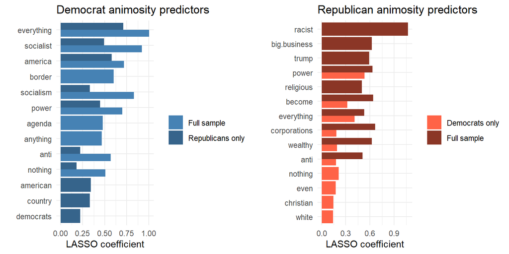

```r
dem_full <- all_results[["1c_dem_skip"]]$coef_df %>%
  filter(class == 1, !is_year) %>%
  arrange(desc(coef)) %>% head(10) %>%
  mutate(sample = "Full sample")

dem_partisan <- robust_results[["R1_dem_rep"]]$coef_df %>%
  filter(class == 1, !is_year) %>%
  arrange(desc(coef)) %>% head(10) %>%
  mutate(sample = "Republicans only")

rep_full <- all_results[["2c_rep_skip"]]$coef_df %>%
  filter(class == 1, !is_year) %>%
  arrange(desc(coef)) %>% head(10) %>%
  mutate(sample = "Full sample")

rep_partisan <- robust_results[["R2_rep_dem"]]$coef_df %>%
  filter(class == 1, !is_year) %>%
  arrange(desc(coef)) %>% head(10) %>%
  mutate(sample = "Democrats only")

p1 <- bind_rows(dem_full, dem_partisan) %>%
  ggplot(aes(x = reorder(term, coef), y = coef, fill = sample)) +
  geom_col(position = "dodge") +
  coord_flip() +
  scale_fill_manual(values = c("steelblue", "steelblue4")) +
  labs(title = "Democrat animosity predictors",
       x = "", y = "LASSO coefficient", fill = "") +
  theme_minimal()

p2 <- bind_rows(rep_full, rep_partisan) %>%
  ggplot(aes(x = reorder(term, coef), y = coef, fill = sample)) +
  geom_col(position = "dodge") +
  coord_flip() +
  scale_fill_manual(values = c("tomato", "tomato4")) +
  labs(title = "Republican animosity predictors",
       x = "", y = "LASSO coefficient", fill = "") +
  theme_minimal()

grid.arrange(p1, p2, ncol = 2)
```

```r
ggsave("data/text_mining_output/viz_robustness_partisan.png",
       arrangeGrob(p1, p2, ncol = 2),
       width = 12, height = 6, dpi = 300)
```

## 3.5 Robustness check 2 - alternate outcome variable (CSES)

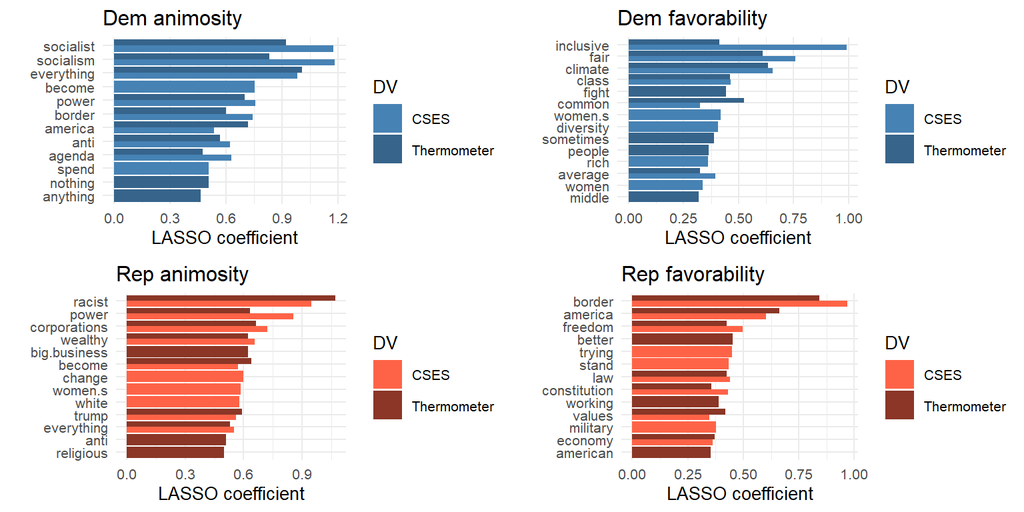

```r
make_comparison_plot <- function(df1, df2, title, colors) {
  bind_rows(df1, df2) %>%
    ggplot(aes(x = reorder(term, coef), y = coef, fill = dv)) +
    geom_col(position = "dodge") +
    coord_flip() +
    scale_fill_manual(values = colors) +
    labs(title = title, x = "", y = "LASSO coefficient", fill = "DV") +
    theme_minimal(base_size = 10)
}

dem_therm_1 <- all_results[["1c_dem_skip"]]$coef_df %>%
  filter(class == 1, !is_year) %>% arrange(desc(coef)) %>% head(10) %>%
  mutate(dv = "Thermometer")

dem_cses_1 <- robust_results[["R3_dem_cses"]]$coef_df %>%
  filter(class == 1, !is_year) %>% arrange(desc(coef)) %>% head(10) %>%
  mutate(dv = "CSES")

dem_therm_5 <- all_results[["1c_dem_skip"]]$coef_df %>%
  filter(class == 5, !is_year) %>% arrange(desc(coef)) %>% head(10) %>%
  mutate(dv = "Thermometer")

dem_cses_5 <- robust_results[["R3_dem_cses"]]$coef_df %>%
  filter(class == 5, !is_year) %>% arrange(desc(coef)) %>% head(10) %>%
  mutate(dv = "CSES")

rep_therm_1 <- all_results[["2c_rep_skip"]]$coef_df %>%
  filter(class == 1, !is_year) %>% arrange(desc(coef)) %>% head(10) %>%
  mutate(dv = "Thermometer")

rep_cses_1 <- robust_results[["R4_rep_cses"]]$coef_df %>%
  filter(class == 1, !is_year) %>% arrange(desc(coef)) %>% head(10) %>%
  mutate(dv = "CSES")

rep_therm_5 <- all_results[["2c_rep_skip"]]$coef_df %>%
  filter(class == 5, !is_year) %>% arrange(desc(coef)) %>% head(10) %>%
  mutate(dv = "Thermometer")

rep_cses_5 <- robust_results[["R4_rep_cses"]]$coef_df %>%
  filter(class == 5, !is_year) %>% arrange(desc(coef)) %>% head(10) %>%
  mutate(dv = "CSES")

p_da <- make_comparison_plot(dem_therm_1, dem_cses_1,
                              "Dem animosity", c("steelblue", "steelblue4"))
p_df <- make_comparison_plot(dem_therm_5, dem_cses_5,
                              "Dem favorability", c("steelblue", "steelblue4"))
p_ra <- make_comparison_plot(rep_therm_1, rep_cses_1,
                              "Rep animosity", c("tomato", "tomato4"))
p_rf <- make_comparison_plot(rep_therm_5, rep_cses_5,
                              "Rep favorability", c("tomato", "tomato4"))

grid.arrange(p_da, p_df, p_ra, p_rf, ncol = 2)
```

```r
ggsave("data/text_mining_output/viz_robustness_cses.png",
       arrangeGrob(p_da, p_df, p_ra, p_rf, ncol = 2),
       width = 12, height = 10, dpi = 300)
```

## 3.6 Relaxed lasso coefficient plot

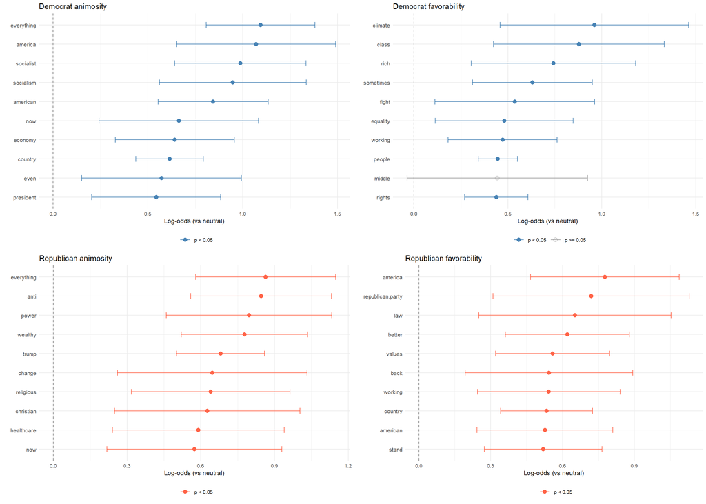

```r
tidy_relaxed <- function(spec_name, class_k, direction = "positive", n = 10) {
  coef_mat <- all_results[[spec_name]]$coef_mat
  se_mat   <- all_results[[spec_name]]$se_mat
  p_mat    <- all_results[[spec_name]]$p_mat

  row_k <- as.character(class_k)

  data.frame(
    term     = colnames(coef_mat),
    estimate = coef_mat[row_k, ],
    se       = se_mat[row_k, ],
    p        = p_mat[row_k, ]
  ) %>%
    filter(!grepl("^\\(Intercept\\)|^year", term)) %>%
    mutate(
      lower = estimate - 1.96 * se,
      upper = estimate + 1.96 * se,
      sig   = ifelse(p < 0.05, "p < 0.05", "p >= 0.05")
    ) %>%
    { if (direction == "positive") arrange(., desc(estimate))
      else arrange(., estimate) } %>%
    head(n)
}

# Build all four plots
p_dem_anim <- tidy_relaxed("1c_dem_skip", class_k = 1, direction = "positive") %>%
  mutate(term = reorder(term, estimate)) %>%
  ggplot(aes(x = term, y = estimate, color = sig, shape = sig)) +
  geom_point(size = 2.5) +
  geom_errorbar(aes(ymin = lower, ymax = upper), width = 0.3) +
  geom_hline(yintercept = 0, linetype = "dashed", color = "gray50") +
  coord_flip() +
  scale_color_manual(values = c("p < 0.05" = "steelblue", "p >= 0.05" = "gray60")) +
  scale_shape_manual(values = c("p < 0.05" = 16, "p >= 0.05" = 1)) +
  labs(title = "Democrat animosity", x = "",
       y = "Log-odds (vs neutral)", color = "", shape = "") +
  theme_minimal(base_size = 9) +
  theme(legend.position = "bottom",
        axis.text.y = element_text(size = 8),
        strip.text = element_text(size = 10, face = "bold"))

p_dem_fav <- tidy_relaxed("1c_dem_skip", class_k = 5, direction = "positive") %>%
  mutate(term = reorder(term, estimate)) %>%
  ggplot(aes(x = term, y = estimate, color = sig, shape = sig)) +
  geom_point(size = 2.5) +
  geom_errorbar(aes(ymin = lower, ymax = upper), width = 0.3) +
  geom_hline(yintercept = 0, linetype = "dashed", color = "gray50") +
  coord_flip() +
  scale_color_manual(values = c("p < 0.05" = "steelblue", "p >= 0.05" = "gray60")) +
  scale_shape_manual(values = c("p < 0.05" = 16, "p >= 0.05" = 1)) +
  labs(title = "Democrat favorability", x = "",
       y = "Log-odds (vs neutral)", color = "", shape = "") +
  theme_minimal(base_size = 9) +
  theme(legend.position = "bottom",
        axis.text.y = element_text(size = 8),
        strip.text = element_text(size = 10, face = "bold"))

p_rep_anim <- tidy_relaxed("2c_rep_skip", class_k = 1, direction = "positive") %>%
  mutate(term = reorder(term, estimate)) %>%
  ggplot(aes(x = term, y = estimate, color = sig, shape = sig)) +
  geom_point(size = 2.5) +
  geom_errorbar(aes(ymin = lower, ymax = upper), width = 0.3) +
  geom_hline(yintercept = 0, linetype = "dashed", color = "gray50") +
  coord_flip() +
  scale_color_manual(values = c("p < 0.05" = "tomato", "p >= 0.05" = "gray60")) +
  scale_shape_manual(values = c("p < 0.05" = 16, "p >= 0.05" = 1)) +
  labs(title = "Republican animosity", x = "",
       y = "Log-odds (vs neutral)", color = "", shape = "") +
  theme_minimal(base_size = 9) +
  theme(legend.position = "bottom",
        axis.text.y = element_text(size = 8),
        strip.text = element_text(size = 10, face = "bold"))

p_rep_fav <- tidy_relaxed("2c_rep_skip", class_k = 5, direction = "positive") %>%
  mutate(term = reorder(term, estimate)) %>%
  ggplot(aes(x = term, y = estimate, color = sig, shape = sig)) +
  geom_point(size = 2.5) +
  geom_errorbar(aes(ymin = lower, ymax = upper), width = 0.3) +
  geom_hline(yintercept = 0, linetype = "dashed", color = "gray50") +
  coord_flip() +
  scale_color_manual(values = c("p < 0.05" = "tomato", "p >= 0.05" = "gray60")) +
  scale_shape_manual(values = c("p < 0.05" = 16, "p >= 0.05" = 1)) +
  labs(title = "Republican favorability", x = "",
       y = "Log-odds (vs neutral)", color = "", shape = "") +
  theme_minimal(base_size = 9) +
  theme(legend.position = "bottom",
        axis.text.y = element_text(size = 8),
        strip.text = element_text(size = 10, face = "bold"))

# Arrange in 2x2 grid
combined <- arrangeGrob(p_dem_anim, p_dem_fav, p_rep_anim, p_rep_fav, ncol = 2)
grid.arrange(p_dem_anim, p_dem_fav, p_rep_anim, p_rep_fav, ncol = 2)
```

```r
ggsave("data/text_mining_output/viz_relaxed_lasso_coefs.png",
       combined, width = 14, height = 10, dpi = 300)
```